# 问题1

```python
import hmz
import sympy
from sympy import *
import numpy as np
import pandas as pd
import matplotlib.pyplot as plt
from IPython import InteractiveShell

plt.rcParams['font.sans-serif'] = ['SimHei']
plt.rcParams['axes.unicode_minus'] = False

import warnings
warnings.filterwarnings('ignore')
```

```python
import os
import sys
from colorama import Fore

default_fore = 'BLUE'

class FORE(object):
    def __init__(self, c=default_fore):
        self.Fore = {
            'BLACK': Fore.BLACK,
            'RED': Fore.RED,
            'GREEN': Fore.GREEN,
            'YELLOW': Fore.YELLOW,
            'BLUE': Fore.BLUE,
            'MAGENTA': Fore.MAGENTA,
            'CYAN': Fore.CYAN,
            'WHITE': Fore.WHITE,
            # 'RESET': Fore.RESET,
        }
        color = c.upper()
        if color not in self.Fore.keys():
            raise ValueError('error 没有该字体颜色')
        self.COLOR = self.Fore[color]

    def __enter__(self):
        print(self.COLOR, end='')

    def __exit__(self, exc_type, exc_val, exc_tb):
        print(Fore.RESET, end='')
```

## 问题 1：

请根据给出的无人车模型的参数，计算车辆最小转弯半径。 如果限制车辆最大加加速度为20 m/s"，无人车沿直线行驶时，最短需要多 少距离能加速到最大限制速度20km/h？当车速为20km/h时，无人车如果 需要转弯，从沿直线行驶状态开始转弯，路径上的曲率相对路径长度的变 化率大小有何限制？

最小转弯半径：转向盘转到极限位置，汽车以最低稳定车速转向行驶时，外侧车轮的中心在支承平面上滚过的轨迹圆半径。

```python
a2r = lambda a: a / 180 * np.pi
r2a = lambda r: r * 180 / np.pi

L = 2.8  # 车子轴距2.8m
car_length = 4.9  # 车身长4.9m
car_width = 1.8  # 车身宽1.8m
K = 1.7  # 轮间距为1.7m
delta = 1  # 车辆的前轮偏角
angle_max_steer_wheel = a2r(470)  # 方向盘最大转角470°
ratio_steer_front = 16  # 方向盘与前轮转角的传动比为16: 1（方向盘转动16°，前轮转动1°）
v_max_steer_wheel = a2r(400)  # 方向盘最大转速为400°/s

Ts = 0.001
v = 50 / 9
```

运动学：

$v$ 车辆的实际速度

$\varphi$ 车辆的航偏角

$x, y$ 车辆横向与纵向的位置

$L$ 轴距

$R$ 转弯半径

$\delta$ 车辆的前轮偏角

$\dot{\varphi} = \omega = \frac{v}{R} \overset{tan\delta = \frac{L}{R}}{=} v * \frac{tan\delta}{L}$

$\begin{align} \dot{x} & = v * cos\varphi\\ \dot{y} & = v * sin\varphi\\ \dot{\varphi} & = v * \frac{tan\delta}{L} \end{align} \Rightarrow \left[\begin{matrix} \dot{x}\\ \dot{y}\\ \dot{\varphi}\\ \end{matrix}\right] = \left[\begin{matrix} cos\varphi\\ sin\varphi\\ \frac{tan\delta}{l}\\ \end{matrix}\right] v$

状态转移方程：

状态量：$X = \left(\begin{matrix} x,y,\varphi \end{matrix}\right)$

控制量：$u = \left(\begin{matrix} v,\delta \end{matrix}\right)$

$\bar{X} = X - X_r$

$\begin{align} \nonumber \bar{X}(k+1) & = & A_{k, t} & \bar{X}(k) + & B_{k, t}\bar{u}(k)\\ \nonumber & = & \left[\begin{matrix} 1 & 0 & {-v_rsin\varphi_rT_s}\\ 0 & 1 & {v_rcos\varphi_rT_s}\\ 0 & 0 & 1\\ \end{matrix}\right] & \bar{X}(k) + & \left[\begin{matrix} {cos\varphi_rT_s} & 0 \\ {sin\varphi_rT_s} & 0 \\ \cfrac{tan\delta_rT_s}{l} & \cfrac{v_rT_s}{lcos^2\delta_r}\\ \end{matrix}\right]\bar{u}(k)\\ \end{align}$

$\delta(k+1) = \omega \Delta T + \delta(k)$

```python
def judge_angle(radian, approach_radian, eps=1):
    """
    :param radian: 弧度
    :param approach_radian: 逼近弧度
    """
    return abs(radian - approach_radian) < a2r(eps)
```

```python
def judge_vertical(delta, varphi, approach_radian, R, L=L, to_print=0):
    """
    :param delta: 弧度
    :param varphi: 弧度
    :param approach_radian: 逼近弧度
    """
    lr = lf = L / 2  # 轴距
    delta_f = delta  # 前轮
    delta_r = 0  # 后轮
#     beta = np.arctan((lf * np.tan(delta_r) + lr * np.tan(delta_f)) / (lf + lr))
    beta = np.arcsin(lr / R)
    if to_print:
        with FORE():
            # print 弧度 角度
            print("beta:\t", round(beta, 5), "\t", round(r2a(beta), 5))
    return judge_angle(beta + varphi, approach_radian)
```

```python
def fA(v, varphi, Ts=Ts):
    return np.array([
        [1, 0, - v * np.sin(varphi) * Ts],
        [0, 1, v * np.cos(varphi) * Ts],
        [0, 0, 1],
    ])
def fB(varphi, delta, l=L, Ts=Ts, v=v):
    return np.array([
        [np.cos(varphi) * Ts, 0],
        [np.sin(varphi) * Ts, 0],
        [np.tan(delta) * Ts / l, v * Ts / l / np.cos(delta)**2],
    ])
def fu(v, delta):
    return np.array([v, delta])

class Locus:
    def __init__(self):
        self.R = None
        self.Rs = None
    def diff_angle(self, angle_=30, to_print=0, state1_time_max=2, state2_times=125):
        """Legacy methods"""
        xs, ys = [], []
        Rs = []
        approach_radian = a2r(angle_)

        x, y, varphi, v, delta, l, Ts = 0, 0, 0, 50/9, 0, L, 0.001
        A = np.array([
            [1, 0, - v * np.sin(varphi) * Ts],
            [0, 1, v * np.cos(varphi) * Ts],
            [0, 0, 1]])
        # A.shape
        X = np.array([x, y, varphi])
        # X.shape
        B = np.array([
            [np.cos(varphi) * Ts, 0],
            [np.sin(varphi) * Ts, 0],
            [np.tan(delta) * Ts / l, v * Ts / l / np.cos(delta)**2]])
        # B.shape
        u = np.array([v, delta])
        # u.shape

        def epo_res(A, X, B, u, delta, to_print=1):
            X = A @ X + B @ u
            x, y, varphi = X
            xs.append(float(x))
            ys.append(float(y))

            A = fA(v, varphi)
            B = fB(varphi, delta)
            u = fu(v, delta)
            R = L / np.tan(delta)

            if to_print:
                with FORE():
                    print("\t弧度\t\t角度")
                    print("x:\t", round(x, 5))
                    print("y:\t", round(y, 5))
                    print("varphi:\t", round(varphi, 5), "\t", round(r2a(varphi), 5))
                    print("v:\t", round(v, 5))
                    print("delta:\t", round(delta, 5), "\t", round(r2a(delta), 5))
                    print("R:\t", round(L / np.tan(delta), 5))
            return A, X, B, u, varphi, R, x, y

        plt.figure(figsize=(8, 6), dpi=81)

        imax = 0
        total_time = 0
        # state1
        for i in range(int(state1_time_max / Ts)):
            total_time += Ts
            if to_print:
                print("t:", total_time)

            delta = a2r(470 / 16) * total_time  # 弧度
            A, X, B, u, varphi, R, x, y = epo_res(A, X, B, u, delta, to_print)
            Rs.append(R)

            if judge_vertical(delta, varphi, approach_radian, R):
                plt.plot(x, y, 'ro')
                imax = i + 1
                break
        # state2
        for i in range(state2_times):
            total_time += Ts
            if to_print:
                print("t:", total_time)
            A, X, B, u, varphi, R, x, y = epo_res(A, X, B, u, delta, to_print)
            Rs.append(R)
        plt.plot(x, y, 'ro')

        # state3
        for i in range(imax):
            total_time += Ts
            if to_print:
                print("t:", total_time)

            delta = a2r(470 / 16) * (imax - i) * Ts  # 弧度
            A, X, B, u, varphi, R, x, y = epo_res(A, X, B, u, delta, to_print)
            Rs.append(R)

            if judge_vertical(delta, varphi, a2r(90), R):
                plt.plot(x, y, 'ro')  # not work
                break

        plt.plot(xs, ys, label='车辆转弯轨迹')
        plt.xlabel('$x$')
        plt.ylabel('$y$')
        plt.savefig('./img/车辆转弯轨迹曲线.svg')
        plt.savefig('./img/车辆转弯轨迹曲线.png')
        plt.show()
        self.Rs = Rs
        self.R = min(Rs)
        return xs, ys
    def run_locus(self):
        t1, t2, t3 = 1.175, 6.6, 1.175
        v0, v1, vstep = 50/9, 50/9+0.01, 0.01
#         v0 = 0.52
#         v1 = 0.53
        for v in np.arange(v0, v1, vstep):
            print("v:", v)
            x, y = 0, 0
            varphi = 0
#             varphi = a2r(90)
            delta = 0
            l = L
            Ts = 0.001
            omega = a2r(400 / 16)
        #     x, y, varphi, delta, l, Ts = 0, 0, 90, 0, L, 0.001
            plt.figure(figsize=(8, 6), dpi=81)
            plt.plot(x, y, 'ko', label='第一阶段开始点', linewidth=2, color='black', linestyle='-', marker='o')
            xs, ys, varphis, deltas = [x], [y], [varphi], [delta]
            def epo_res(t, omega, x, y, varphi, delta, l=L, Ts=Ts):
                for _ in range(int(t/Ts)):
                    x = Ts * np.cos(varphi) * v + x
                    y = Ts * np.sin(varphi) * v + y
                    varphi = Ts * np.tan(delta) / l + varphi
                    delta = Ts * omega + delta
                    xs.append(x)
                    ys.append(y)
                    varphis.append(varphi)
                    deltas.append(delta)
                return x, y, varphi, delta
            print(f"start varphi: {r2a(varphi)}°")

            x, y, varphi, delta = epo_res(t1, omega, x, y, varphi, delta)
            plt.plot(x, y, label='第二阶段开始点', linewidth=2, color='blue', linestyle='-', marker='o')
            x, y, varphi, delta = epo_res(t2, 0, x, y, varphi, delta)
            plt.plot(x, y, label='第三阶段开始点', linewidth=2, color='red', linestyle='-', marker='o')
            x, y, varphi, delta = epo_res(t3, -omega, x, y, varphi, delta)

            pd.DataFrame([xs, ys, varphis, deltas], index=["xs", "ys", "varphis", "deltas"]).T.head()

            print(f"final varphi: {round(r2a(varphi), 3)}°")
            ys = np.array(ys)
            newys = abs(np.array(ys) - 2.75)
            print(min(newys))
            print(ys[np.argsort(newys)[0]])

            plt.title('车辆转弯轨迹')
            plt.plot(xs, ys, color='skyblue', label='车辆转弯轨迹')
            plt.xlabel('$x$')
            plt.ylabel('$y$')
            plt.legend()
            plt.savefig('./img/车辆转弯轨迹曲线.svg')
#             plt.savefig('./img/车辆转弯轨迹曲线.png')
            plt.show()
        return xs, ys
```

```
v: 5.555555555555555
start varphi: 0.0°
final varphi: 88.918°
0.001169058483358576
2.7488309415166414
```

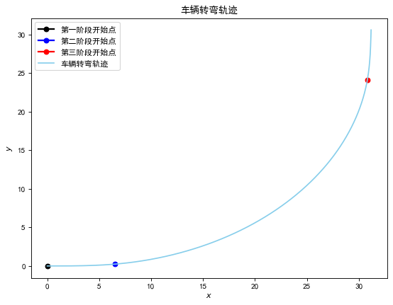

```python
locus = Locus()
xs, ys = locus.run_locus()
```

### 使用两个指数函数进行拟合

```python
# TODO fitting
from hmz.math_model.fitting import Fitting

def fit_func(p):
    return lambda x: p[0] * np.exp(-x / p[1]) + p[2] * np.exp(-x / p[3]) + p[4]

fitting = Fitting(fit_type='func_fit')
# for x0 in np.arange(-0.1, -1.5, -0.05):
#     print(x0)
#     y_fit, factor = fitting.fit(np.array(xs), np.array(ys), n=5, x0=[0, -0.28, 0, x0, 0], fit_func=fit_func)
#     print(factor)
y_fit, factor = fitting.fit(np.array(xs), np.array(ys), n=5, x0=[0, -0.28, 0, -1.4, 0], fit_func=fit_func)
print(factor)
```

```
  回归平方和 RSS：804542.3320140856
  残差平方和 ESS：10907.506921274857
  总体平方和 TSS：815449.8334330695
    拟合优度 R^2：0.9866239387463556

accuracy: -inf
[-5.65593866e-43 -4.38912768e-01  1.82442232e-01 -6.28256365e+00
  2.52818896e-01]
```

```python
x = symbols('x')
args = factor
def f(x, p=args):
#     return p[0] * (x - p[1])**p[2] + p[3]
    return p[0] * np.exp(-x / p[1]) + p[2] * np.exp(-x / p[3]) + p[4]
```

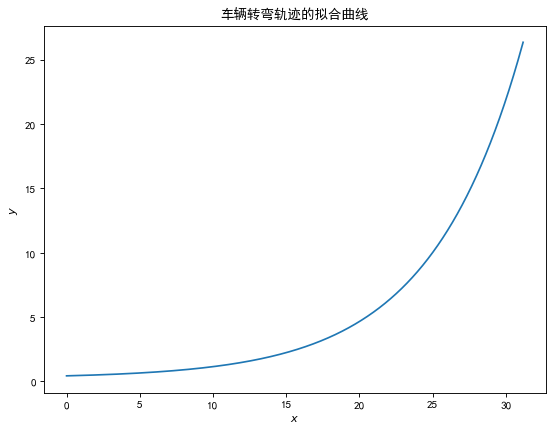

```python
# 拟合曲线
InteractiveShell.ast_node_interactivity = 'last'
plt.figure(figsize=(8, 6), dpi=81)
plt.plot(xs, list(map(f, xs)))
plt.xlabel("$x$")
plt.ylabel("$y$")
plt.title('车辆转弯轨迹的拟合曲线')
plt.savefig('./img/车辆转弯轨迹的拟合曲线.svg')
plt.show()
```

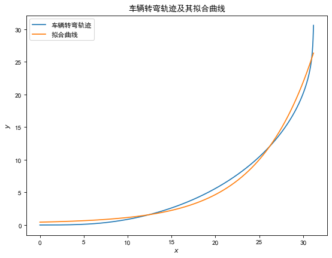

```python
# 车辆转弯轨迹、拟合曲线
InteractiveShell.ast_node_interactivity = 'last'
plt.figure(figsize=(8, 6), dpi=81)
plt.plot(xs, ys)
plt.plot(xs, list(map(f, xs)), label='拟合曲线')
plt.xlabel("$x$")
plt.ylabel("$y$")
plt.title('车辆转弯轨迹及其拟合曲线')
plt.legend(labels=['车辆转弯轨迹','拟合曲线'], loc='best')
plt.savefig('./img/车辆转弯轨迹及其拟合曲线.svg')
plt.show()
```

```python
InteractiveShell.ast_node_interactivity = 'all'
InteractiveShell.ast_node_interactivity = 'all'

x = sympy.symbols('x')
p = args
y = p[0] * sympy.exp(-x / p[1]) + p[2] * sympy.exp(-x / p[3]) + p[4]
y_ = diff(y, x)
y__ = diff(y_, x)
y___ = diff(y__, x)
y
y_
y__
y___
```

$\displaystyle 0.182442232389461 e^{0.159170691300153 x} - 5.65593866466131 \cdot 10^{-43} e^{2.27835705100741 x} + 0.252818896200039$

$\displaystyle 0.0290394562517737 e^{0.159170691300153 x} - 1.28862477366965 \cdot 10^{-42} e^{2.27835705100741 x}$

$\displaystyle 0.00462223032657538 e^{0.159170691300153 x} - 2.93594733919308 \cdot 10^{-42} e^{2.27835705100741 x}$

$\displaystyle 0.000735723596429536 e^{0.159170691300153 x} - 6.68913632163698 \cdot 10^{-42} e^{2.27835705100741 x}$

```python
InteractiveShell.ast_node_interactivity = 'all'
InteractiveShell.ast_node_interactivity = 'all'
k = y__ / (1 + y_**2) ** (3/2)
k
k_ = (y___ + y___ * y_**2 - 3 * y_ * y__**2) / (1 + y_**2)**3
k_
```

$\displaystyle \frac{0.00462223032657538 e^{0.159170691300153 x} - 2.93594733919308 \cdot 10^{-42} e^{2.27835705100741 x}}{\left(0.000843290019398678 \left(e^{0.159170691300153 x} - 4.4374962206496 \cdot 10^{-41} e^{2.27835705100741 x}\right)^{2} + 1\right)^{1.5}}$

$\displaystyle \frac{0.000843290019398678 \cdot \left(0.000735723596429536 e^{0.159170691300153 x} - 6.68913632163698 \cdot 10^{-42} e^{2.27835705100741 x}\right) \left(e^{0.159170691300153 x} - 4.4374962206496 \cdot 10^{-41} e^{2.27835705100741 x}\right)^{2} - 2.13650131919131 \cdot 10^{-5} \cdot \left(0.0871183687553211 e^{0.159170691300153 x} - 3.86587432100895 \cdot 10^{-42} e^{2.27835705100741 x}\right) \left(e^{0.159170691300153 x} - 6.3517980103954 \cdot 10^{-40} e^{2.27835705100741 x}\right)^{2} + 0.000735723596429536 e^{0.159170691300153 x} - 6.68913632163698 \cdot 10^{-42} e^{2.27835705100741 x}}{\left(0.000843290019398678 \left(e^{0.159170691300153 x} - 4.4374962206496 \cdot 10^{-41} e^{2.27835705100741 x}\right)^{2} + 1\right)^{3}}$

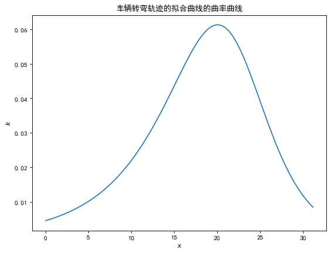

```python
# 曲率曲线（这里计算时间需要 1-5 min）
InteractiveShell.ast_node_interactivity = 'last'
InteractiveShell.ast_node_interactivity = 'last'
ks = []
for i in xs:
    ks.append(k.subs(x, i))

plt.figure(figsize=(8, 6), dpi=81)
plt.plot(xs, ks)
plt.xlabel("$x$")
plt.ylabel("$k$")
plt.title('车辆转弯轨迹的拟合曲线的曲率曲线')
plt.savefig('./img/车辆转弯轨迹的拟合曲线的曲率曲线.svg')
plt.show()
```

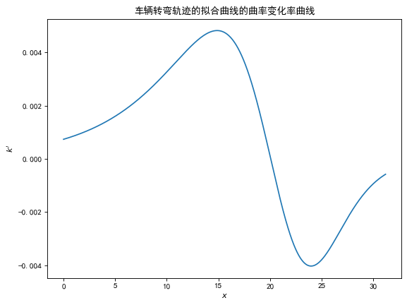

```python
# 曲率变化率曲线（这里计算时间需要 1-5 min）
InteractiveShell.ast_node_interactivity = 'last'
InteractiveShell.ast_node_interactivity = 'last'
k_s = []
for i in xs:
    k_s.append(k_.subs(x, i))

plt.figure(figsize=(8, 6), dpi=81)
plt.plot(xs, k_s)
plt.xlabel("$x$")
plt.ylabel("$k'$")
plt.title('车辆转弯轨迹的拟合曲线的曲率变化率曲线')
plt.savefig('./img/车辆转弯轨迹的拟合曲线的曲率变化率曲线.svg')
plt.show()
```

### 求能加速到最大限制速度 $20km/h$ 的最短距离

$a = \begin{cases} 20t & [0, \cfrac{3}{20}] \\ 3 & [\cfrac{3}{20}, \cfrac{50}{27}] \\ -20t + \cfrac{1081}{27} & [\cfrac{50}{27}, \cfrac{1081}{540}] \\ \end{cases}$

$v = \begin{cases} 10t^2 & [0, \cfrac{3}{20}] \\ 3t - \cfrac{9}{40} & [\cfrac{3}{20}, \cfrac{50}{27}] \\ -10t^2 + \cfrac{1081}{27}t - \cfrac{1006561}{29160} & [\cfrac{50}{27}, \cfrac{1081}{540}] \\ \end{cases}$

$s = \begin{cases} \cfrac{10}{3}t^3 & [0, \cfrac{3}{20}] \\ \cfrac{3}{2}t^2 - \cfrac{9}{40}t + \cfrac{9}{800} & [\cfrac{3}{20}, \cfrac{50}{27}] \\ -\cfrac{10}{3}t^3 + \cfrac{1081}{54}t^2 - \cfrac{1006561}{29160}t + 21.19 & [\cfrac{50}{27}, \cfrac{1081}{540}] \\ \end{cases}$

```
x1: 0.0112500000000000
x2: 4.72736625514403
x3: 0.822083333333325
5.56069958847736
```

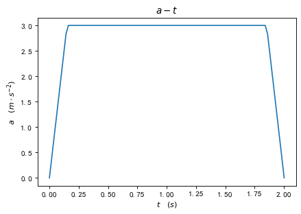

[figure not shown]

[figure not shown]

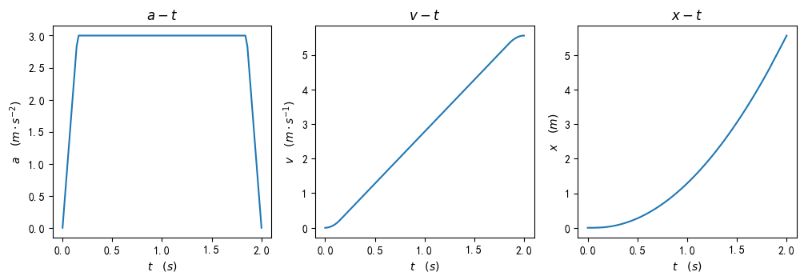

```python
import sympy
from sympy import *
from sympy.abc import x, y, z, a

from IPython.core.interactiveshell import InteractiveShell
InteractiveShell.ast_node_interactivity = 'all'  # 'last_expr'

class AVX:
    def __init__(self):
        self.t = sympy.symbols('t')
        self.bounds = (0, 3 / 20, 50 / 27, 1081 / 540)

        self.a1 = 20 * self.t**1
        self.a2 = 3 * self.t**0
        self.a3 = -20 * self.t**1 + 1081 / 27

        self.v1 = 10 * self.t**2
        self.v2 = 3 * self.t**1 - 9 / 40
        self.v3 = -10 * self.t**2 + 1081 / 27 * self.t - 1006561 / 29160

        self.x1 = 10 / 3 * self.t**3
        self.x2 = 3 / 2 * self.t**2 - 9 / 40 * self.t + 9 / 800
        self.x3 = -10 / 3 * self.t**3 + 1081 / 54 * self.t**2 - 1006561 / 29160 * self.t + 21.19
    def a(self):
        return None
    def v(self):
        return None
    def x(self):
        x1 = self.x1.subs(self.t, self.bounds[1]) - self.x1.subs(self.t, self.bounds[0])
        x2 = self.x2.subs(self.t, self.bounds[2]) - self.x2.subs(self.t, self.bounds[1])
        x3 = self.x3.subs(self.t, self.bounds[3]) - self.x3.subs(self.t, self.bounds[2])
        print("x1:", x1)
        print("x2:", x2)
        print("x3:", x3)
        return x1 + x2 + x3
    def fa(self, t):
        if t < self.bounds[1]:
            return self.a1.subs(self.t, t)
        elif t < self.bounds[2]:
            return self.a2.subs(self.t, t)
        else:
            return self.a3.subs(self.t, t)
    def fv(self, t):
        if t < self.bounds[1]:
            return self.v1.subs(self.t, t)
        elif t < self.bounds[2]:
            return self.v2.subs(self.t, t)
        else:
            return self.v3.subs(self.t, t)
    def fx(self, t):
        if t < self.bounds[1]:
            return self.x1.subs(self.t, t)
        elif t < self.bounds[2]:
            return self.x2.subs(self.t, t)
        else:
            return self.x3.subs(self.t, t)
    def plot_a(self):
        x = np.linspace(self.bounds[0], self.bounds[-1], 100)
        y = list(map(self.fa, x))
        plt.figure(dpi=81)
        plt.plot(x, y)
#         plt.plot(x, y, c='skyblue')
        plt.title("$a-t$")
        plt.xlabel("$t \quad (s)$")
        plt.ylabel("$a \quad (m \cdot s^{-2})$")
        plt.savefig('./img/a-t.svg')
        plt.show()
        return plt
    def plot_v(self):
        x = np.linspace(self.bounds[0], self.bounds[-1], 100)
        y = list(map(self.fv, x))
        plt.figure(dpi=81)
        plt.plot(x, y)
#         plt.plot(x, y, c='skyblue')
        plt.title("$a-t$")
        plt.xlabel("$t \quad (s)$")
        plt.ylabel("$a \quad (m \cdot s^{-1})$")
        plt.savefig('./img/v-t.svg')
        plt.show()
        return plt
    def plot_x(self):
        x = np.linspace(self.bounds[0], self.bounds[-1], 100)
        y = list(map(self.fx, x))
        plt.figure(dpi=81)
        plt.plot(x, y)
#         plt.plot(x, y, c='skyblue')
        plt.title("$a-t$")
        plt.xlabel("$t \quad (s)$")
        plt.ylabel("$x \quad (m)$")
        plt.savefig('./img/x-t.svg')
        plt.show()
        return plt
    def plot_all(self):
        t = np.linspace(self.bounds[0], self.bounds[-1], 100)
        plt.figure(figsize=(12, 3.5), dpi=100)

        a = list(map(self.fa, t))
        plt.subplot(131)
        plt.plot(t, a)
#         plt.plot(t, x, c='r')
#         plt.plot(t, a, c='skyblue')
        plt.title("$a-t$")
        plt.xlabel("$t \quad (s)$")
        plt.ylabel("$a \quad (m \cdot s^{-2})$")

        v = list(map(self.fv, t))
        plt.subplot(132)
        plt.plot(t, v)
#         plt.plot(t, v, c='g')
#         plt.plot(t, v, c='skyblue')
        plt.title("$v-t$")
        plt.xlabel("$t \quad (s)$")
        plt.ylabel("$v \quad (m \cdot s^{-1})$")

        x = list(map(self.fx, t))
        plt.subplot(133)
        plt.plot(t, x)
#         plt.plot(t, x, c='b')
#         plt.plot(t, x, c='skyblue')
        plt.title("$x-t$")
        plt.xlabel("$t \quad (s)$")
        plt.ylabel("$x \quad (m)$")

        plt.savefig('./img/avx-t.svg')
        plt.show()
        return None

avx = AVX()
print(avx.x())
plt_a = avx.plot_a()
plt_v = avx.plot_v()
plt_x = avx.plot_x()
avx.plot_all()
```